# Transit in LA and Chicago

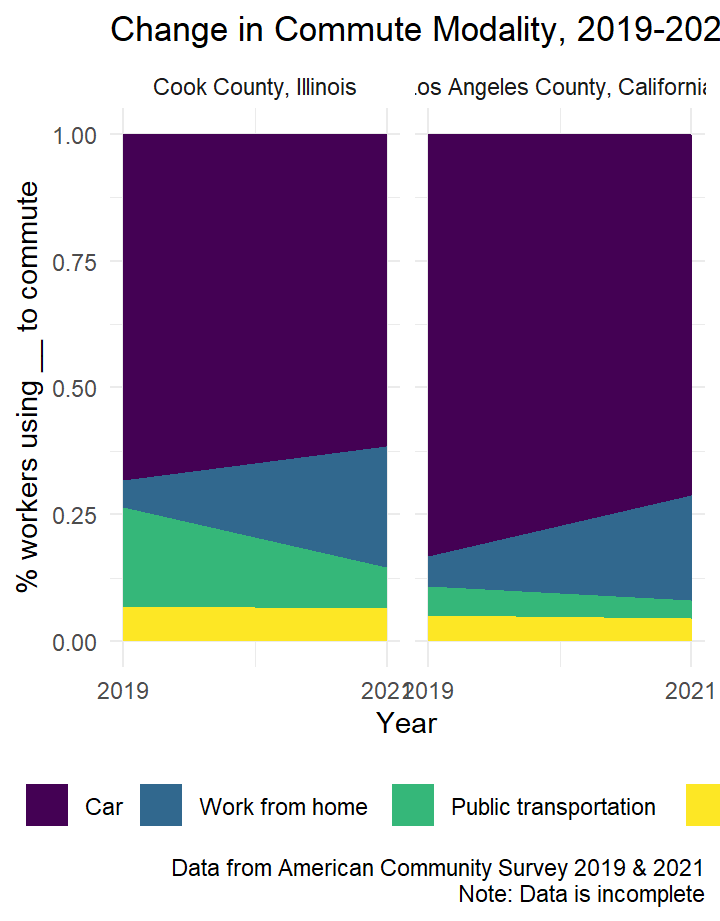

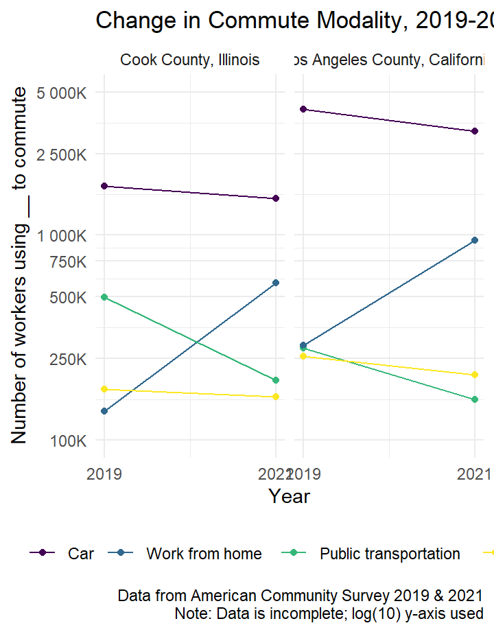

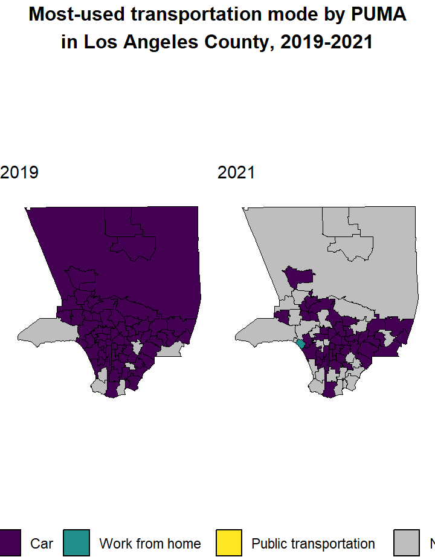

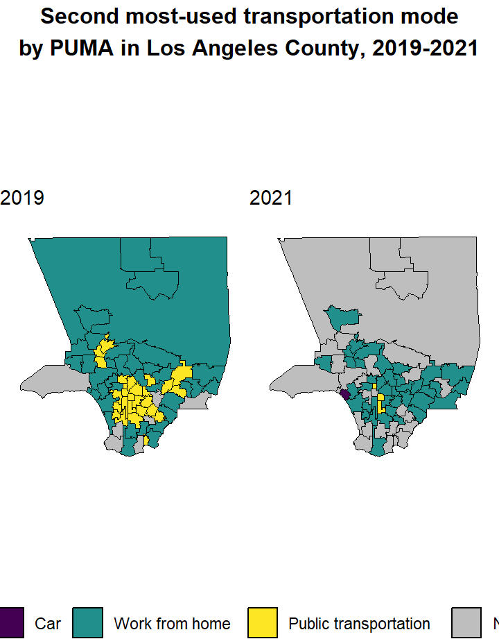

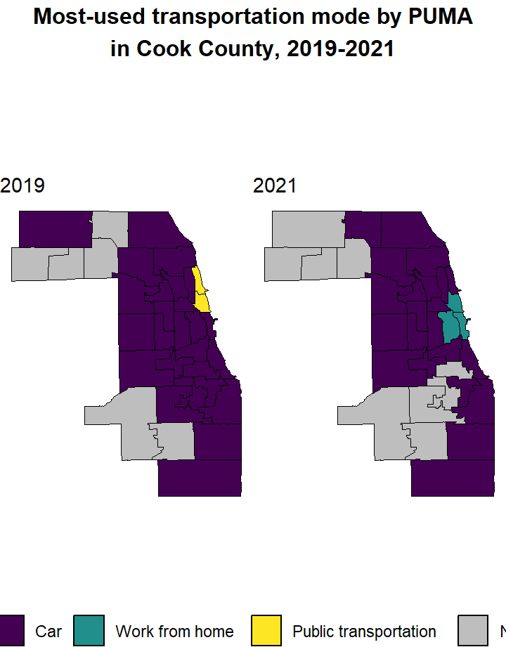

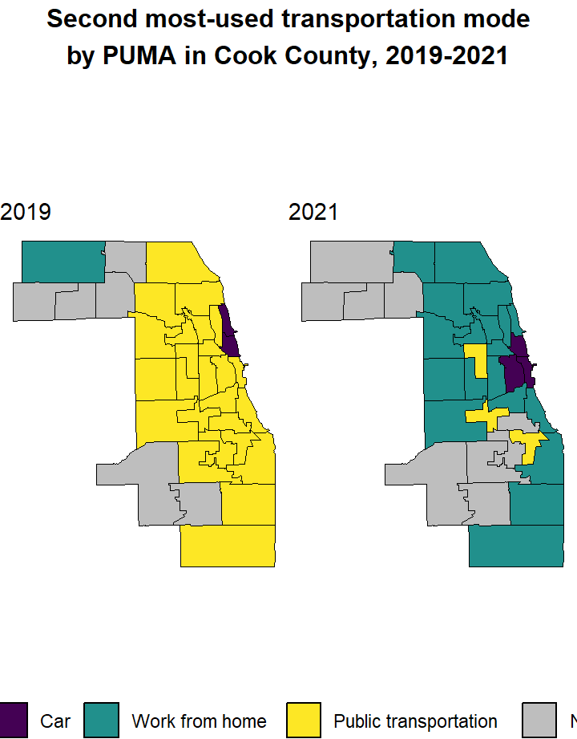

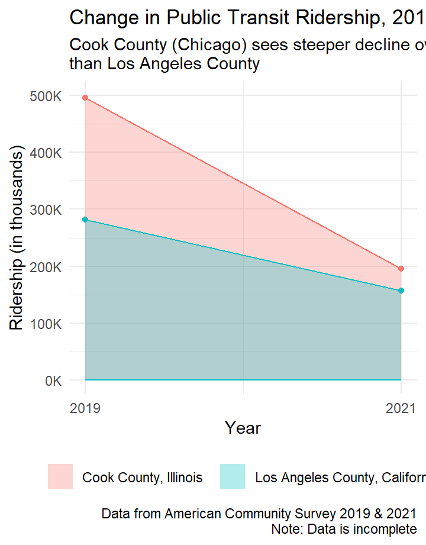

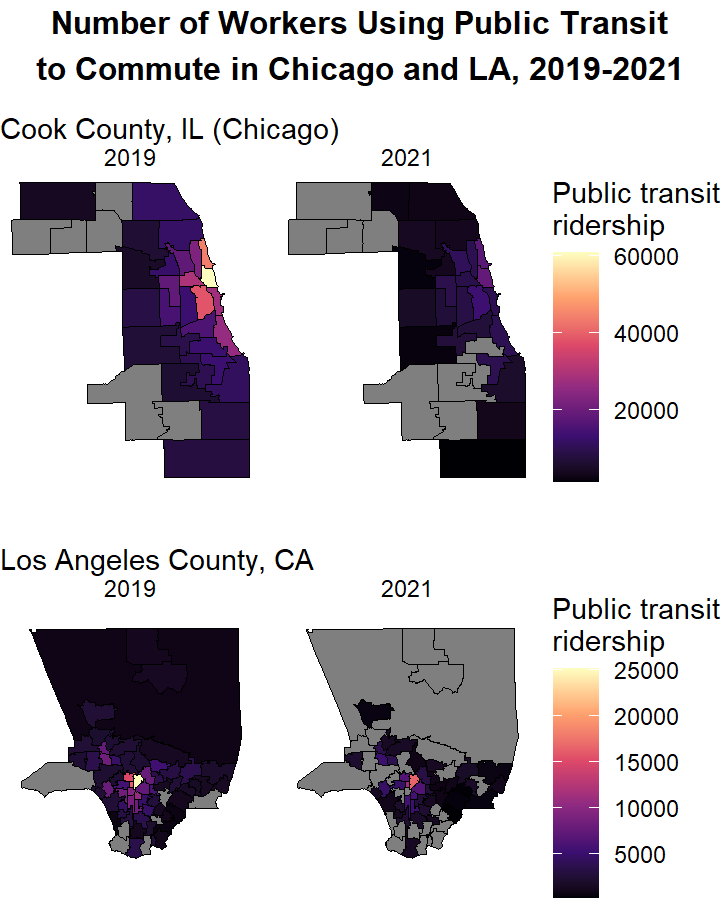

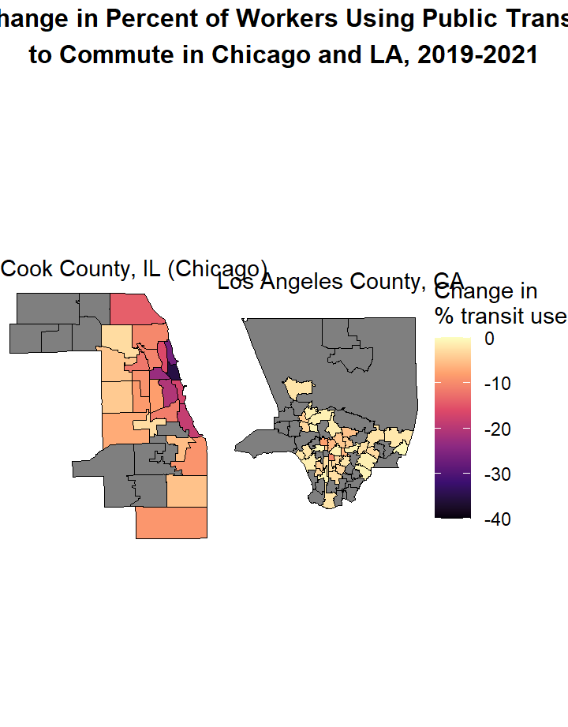

# About

**What is the purpose of this dashboard?**

The purpose of this dashboard is to compare changes in public transit use (and other forms of transportation) over the pandemic in Los Angeles, CA and Chicago, IL.

**Where do the data come from?**

The datasets used in this dashboard are from the [1-Year American Community Survey (ACS)](https://www.census.gov/data/developers/data-sets/acs-1year.html) in [2019](https://www.census.gov/newsroom/press-kits/2020/acs-1year.html) and [2021](https://www.census.gov/newsroom/press-kits/2022/acs-1year.html). The data were obtained from the ACS using the [tidycensus](https://walker-data.com/tidycensus/) API in R.

### Navigating the dashboard

**Here’s a two-minute overview of this dashboard:**

[video not shown]

# The Data

### Los Angeles 2019/2021 (PUMA-level)

This dataset contains estimates of various transportation mode uses (car, public transit, and work from home) by 2010 Census [Public Use Microdata Area (PUMA)](https://www.census.gov/programs-surveys/geography/guidance/geo-areas/pumas.html#overview) in Los Angeles County, CA in 2019 and 2021.

|  | GEOID | NAME | total_workers_2019 | car_users_2019 | transit_users_2019 | work_from_home_2019 | total_workers_2021 | car_users_2021 | transit_users_2021 | work_from_home_2021 | raw_change_transit | perc_transit_2019 | perc_transit_2021 | perc_change_transit | raw_change_car | perc_car_2019 | perc_car_2021 | perc_change_car | raw_change_wfh | perc_wfh_2019 | perc_wfh_2021 | perc_change_wfh |
| --- | --- | --- | --- | --- | --- | --- | --- | --- | --- | --- | --- | --- | --- | --- | --- | --- | --- | --- | --- | --- | --- | --- |
| 1 | 0603768 | Los Angeles County (Southwest)--Palos Verdes Peninsula PUMA, California |  |  |  |  |  |  |  |  |  |  |  |  |  |  |  |  |  |  |  |  |
| 2 | 0603701 | Los Angeles County (North/Unincorporated)--Castaic PUMA, California | 58216 | 51651 | 935 | 4465 |  |  |  |  |  | 1.606087673491823 |  |  |  | 88.72303146901196 |  |  |  | 7.669712793733681 |  |  |
| 3 | 0603761 | Los Angeles County (South Central)--Torrance City PUMA, California |  |  |  |  |  |  |  |  |  |  |  |  |  |  |  |  |  |  |  |  |
| 4 | 0603709 | Los Angeles County (Central)--San Gabriel Valley Region (North) PUMA, California | 53886 | 45940 | 1456 | 5059 |  |  |  |  |  | 2.702000519615484 |  |  |  | 85.254054856549 |  |  |  | 9.38833834391122 |  |  |
| 5 | 0603750 | Los Angeles County (South Central)--LA City (South Central/Westmont) PUMA, California | 87994 | 72509 | 8839 | 2970 | 72910 | 56784 | 5558 | 7104 | -3281 | 10.04500306839103 | 7.623096968865725 | -2.421906099525303 | -15725 | 82.4022092415392 | 77.88232066931833 | -4.519888572220864 | 4134 | 3.375230129327 | 9.743519407488686 | 6.368289278161686 |
| 6 | 0603756 | Los Angeles County (Southeast)--Bellflower &amp; Paramount Cities PUMA, California |  |  |  |  | 51322 | 41544 | 1483 | 6830 |  |  | 2.889599002377148 |  |  |  | 80.94774170920853 |  |  |  | 13.30813296442072 |  |
| 7 | 0603745 | Los Angeles County (Central)--LA City (Southeast/East Vernon) PUMA, California | 53036 | 35489 | 10692 | 722 | 56340 | 43552 | 5671 | 2915 | -5021 | 20.15989139452447 | 10.06567270145545 | -10.09421869306902 | 8063 | 66.91492571083792 | 77.30209442669506 | 10.38716871585714 | 2193 | 1.361339467531488 | 5.173943911963081 | 3.812604444431593 |
| 8 | 0603733 | Los Angeles County (Central)--LA City (Central/Koreatown) PUMA, California | 64048 | 38890 | 16427 | 2778 | 53319 | 30703 | 11117 | 7894 | -5310 | 25.64795153634774 | 20.84997843170352 | -4.797973104644221 | -8187 | 60.72008493629778 | 57.58360059265928 | -3.1364843436385 | 5116 | 4.337371971021733 | 14.80522890526829 | 10.46785693424656 |
| 9 | 0603749 | Los Angeles County (Central)--Inglewood City PUMA, California | 57313 | 45368 | 4614 | 2537 | 51321 | 37389 | 2172 | 8731 | -2442 | 8.050529548270026 | 4.232185654995031 | -3.818343893274995 | -7979 | 79.15830614345786 | 72.85321798094347 | -6.305088162514394 | 6194 | 4.426569888158009 | 17.01252898423647 | 12.58595909607846 |
| 10 | 0603746 | Los Angeles County--LA City (Central/Univ. of Southern California &amp; Exposition Park) PUMA, California | 53819 | 34342 | 9597 | 2978 |  |  |  |  |  | 17.83199241903417 |  |  |  | 63.81017856147457 |  |  |  | 5.53336182389119 |  |  |

[output cut: 59 more lines]

### Chicago 2019/2021 (PUMA-level)

This dataset contains estimates of various transportation mode uses (car, public transit, and work from home) by 2010 Census [Public Use Microdata Area (PUMA)](https://www.census.gov/programs-surveys/geography/guidance/geo-areas/pumas.html#overview) in Cook County, IL in 2019 and 2021.

|  | GEOID | NAME | total_workers_2019 | car_users_2019 | transit_users_2019 | work_from_home_2019 | total_workers_2021 | car_users_2021 | transit_users_2021 | work_from_home_2021 | raw_change_transit | perc_transit_2019 | perc_transit_2021 | perc_change_transit | raw_change_car | perc_car_2019 | perc_car_2021 | perc_change_car | raw_change_wfh | perc_wfh_2019 | perc_wfh_2021 | perc_change_wfh |
| --- | --- | --- | --- | --- | --- | --- | --- | --- | --- | --- | --- | --- | --- | --- | --- | --- | --- | --- | --- | --- | --- | --- |
| 1 | 1703413 | Cook County (Southeast)--Thornton Township PUMA, Illinois | 74338 | 60683 | 8052 | 2844 | 58338 | 45146 | 3343 | 6936 | -4709 | 10.83160698431489 | 5.730398710960266 | -5.10120827335462 | -15537 | 81.63119804137857 | 77.38695190099078 | -4.244246140387787 | 4092 | 3.825768785816138 | 11.88933456752031 | 8.063565781704176 |
| 2 | 1703530 | Chicago City (South)--Ashburn, Washington Heights, Morgan Park &amp; Beverly PUMA; Illinois | 55280 | 40311 | 9735 | 2754 |  |  |  |  |  | 17.6103473227207 |  |  |  | 72.92149059334298 |  |  |  | 4.981910274963821 |  |  |
| 3 | 1703521 | Chicago City (West)--Austin, Belmont Cragin &amp; Montclare PUMA; Illinois | 85006 | 61868 | 18489 | 1755 | 73059 | 52081 | 9133 | 8399 | -9356 | 21.75022939557208 | 12.5008554729739 | -9.24937392259818 | -9787 | 72.78074488859609 | 71.28622072571483 | -1.494524162881262 | 6644 | 2.064560148695386 | 11.49618801242831 | 9.431627863732924 |
| 4 | 1703501 | Chicago City (North)--Edgewater, Uptown &amp; Rogers Park PUMA; Illinois | 99703 | 36153 | 44241 | 9644 | 96222 | 36375 | 17168 | 33596 | -27073 | 44.37278717791842 | 17.84207353827607 | -26.53071363964235 | 222 | 36.26069426195802 | 37.80320508823346 | 1.542510826275446 | 23952 | 9.672728002166435 | 34.91509218266093 | 25.24236418049449 |
| 5 | 1703528 | Chicago City (South)--Chicago Lawn, Englewood/West Englewood &amp; Greater Grand Crossing PUMA; Illinois | 44310 | 28148 | 12643 | 1847 |  |  |  |  |  | 28.53306251410517 |  |  |  | 63.52516361995036 |  |  |  | 4.168359286842699 |  |  |
| 6 | 1703417 | Cook County (Northwest)--Hanover &amp; Schaumburg (Northwest) Townships PUMA, Illinois |  |  |  |  |  |  |  |  |  |  |  |  |  |  |  |  |  |  |  |  |
| 7 | 1703523 | Chicago City (West)--North &amp; South Lawndale, Humboldt Park, East &amp; West Garfield Park PUMA; Illinois | 63020 | 43780 | 12864 | 2147 | 67236 | 44088 | 8279 | 9196 | -4585 | 20.41256743890828 | 12.31334404188233 | -8.099223397025957 | 308 | 69.47000952078706 | 65.57201499196859 | -3.897994528818472 | 7049 | 3.406854966677245 | 13.67719673984175 | 10.27034177316451 |
| 8 | 1703526 | Chicago City (Southwest)--Brighton Park, New City, Bridgeport &amp; McKinley Park PUMA; Illinois | 72872 | 48976 | 15588 | 2896 | 69991 | 48955 | 6978 | 10434 | -8610 | 21.39093204523 | 9.969853266848595 | -11.4210787783814 | -21 | 67.20825557141289 | 69.944707176637 | 2.736451605224104 | 7538 | 3.974091557799978 | 14.90763098112614 | 10.93353942332616 |
| 9 | 1703527 | Chicago City (Southwest)--Gage Park, Garfield Ridge &amp; West Lawn PUMA; Illinois | 66505 | 52481 | 9148 | 1272 | 64473 | 49841 | 7087 | 5305 | -2061 | 13.75535674009473 | 10.99219828455322 | -2.763158455541506 | -2640 | 78.91286369445906 | 77.30522854528252 | -1.607635149176545 | 4033 | 1.912638147507706 | 8.228250585516419 | 6.315612438008712 |
| 10 | 1703414 | Cook County (South)--Bloom &amp; Rich Townships PUMA, Illinois | 74316 | 60047 | 7789 | 3520 | 64415 | 49009 | 1000 | 10547 | -6789 | 10.48091931750902 | 1.552433439416285 | -8.928485878092731 | -11038 | 80.79955864147693 | 76.08321043235271 | -4.71634820912422 | 7027 | 4.736530491415039 | 16.37351548552356 | 11.63698499410852 |

[output cut: 24 more lines]

### County-level (2019 and 2021)

This dataset contains county-wide estimates of various transportation mode uses (car, public transit, and work from home) in Cook County, IL and Los Angeles County, CA in 2019 and 2021.

|  | GEOID | NAME | variable | estimate | moe | year |
| --- | --- | --- | --- | --- | --- | --- |
| 1 | 06037 | Los Angeles County, California | total_workers | 4931598 | 16610 | 2019 |
| 2 | 06037 | Los Angeles County, California | car_users | 4103368 | 19620 | 2019 |
| 3 | 06037 | Los Angeles County, California | transit_users | 281544 | 9475 | 2019 |
| 4 | 06037 | Los Angeles County, California | work_from_home | 289663 | 9908 | 2019 |
| 5 | 06037 | Los Angeles County, California | total_workers | 4535263 | 21381 | 2021 |
| 6 | 06037 | Los Angeles County, California | car_users | 3223267 | 22634 | 2021 |
| 7 | 06037 | Los Angeles County, California | transit_users | 157360 | 6283 | 2021 |
| 8 | 06037 | Los Angeles County, California | work_from_home | 946616 | 19198 | 2021 |
| 9 | 17031 | Cook County, Illinois | total_workers | 2552596 | 15516 | 2019 |
| 10 | 17031 | Cook County, Illinois | car_users | 1739944 | 18324 | 2019 |

[output cut: 6 more lines]

# Countywide Commute Modality

### Percent Ridership by Modality

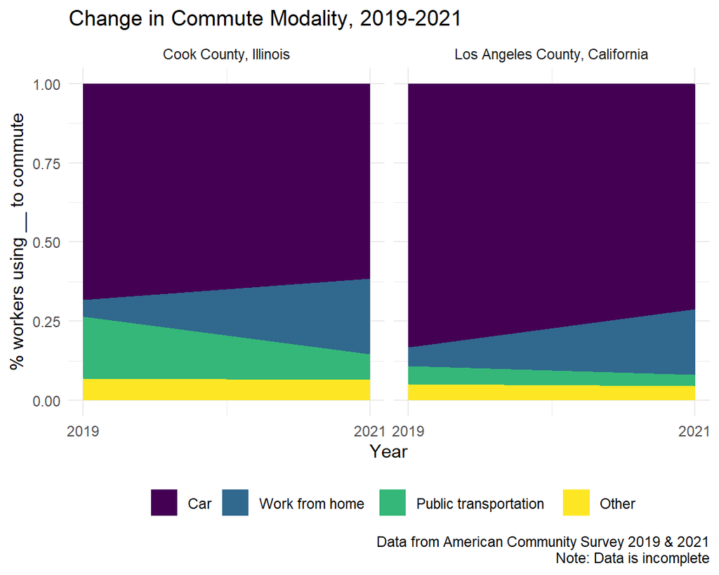

### Raw Ridership by Modality

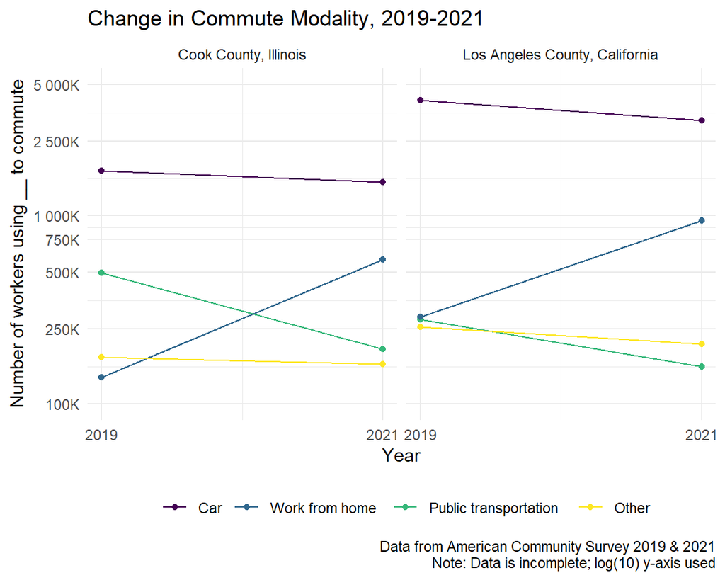

# Los Angeles

### First place

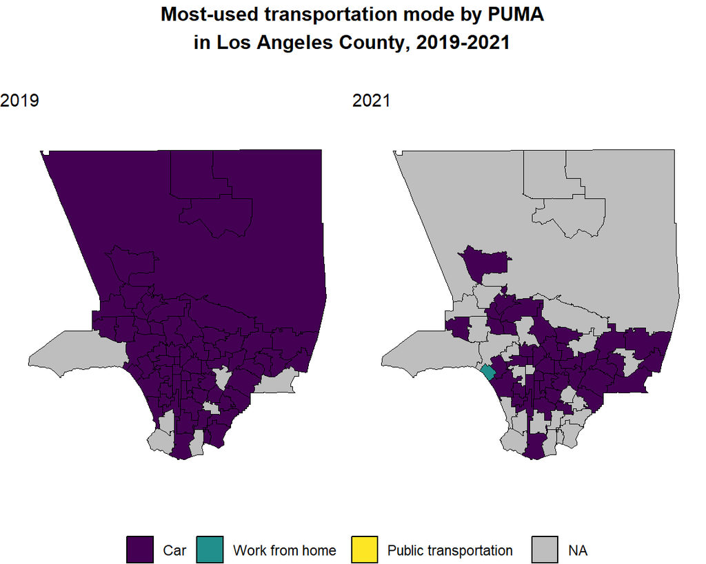

### Second place

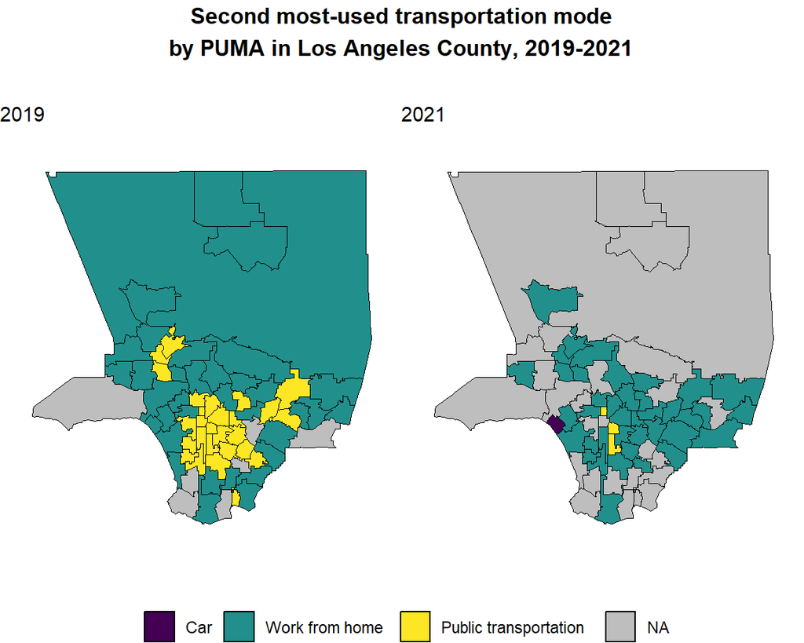

# Chicago

### First place

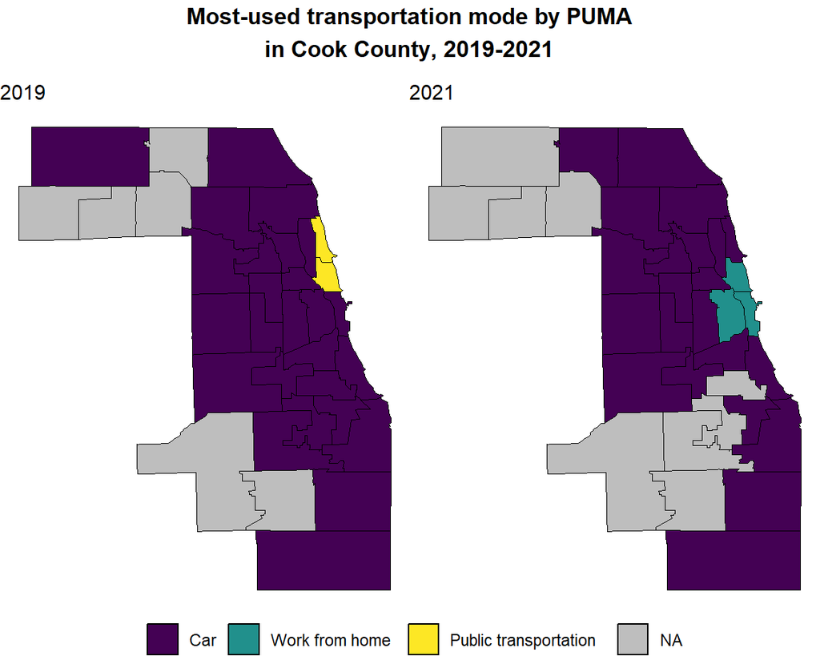

### Second place

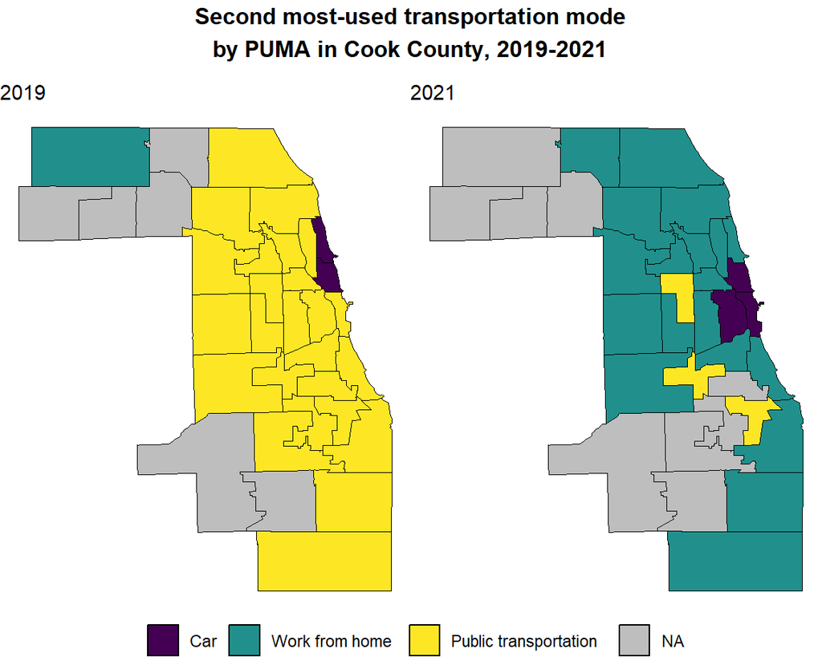

# Active 1

# Active 2

# Analysis

### Change in Countywide Public Transit Ridership

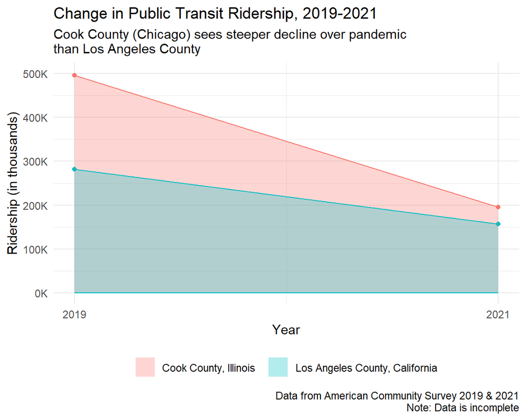

### Change in Transit Ridership by PUMA

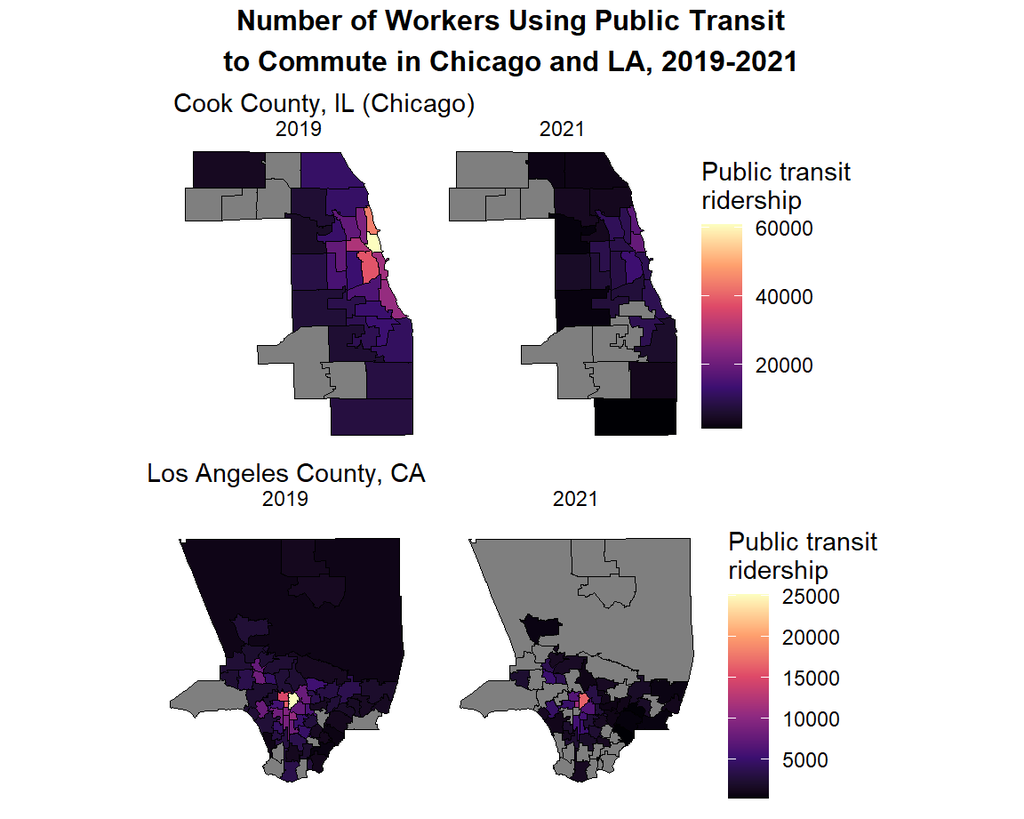

### Change in Percent Transit Ridership by PUMA

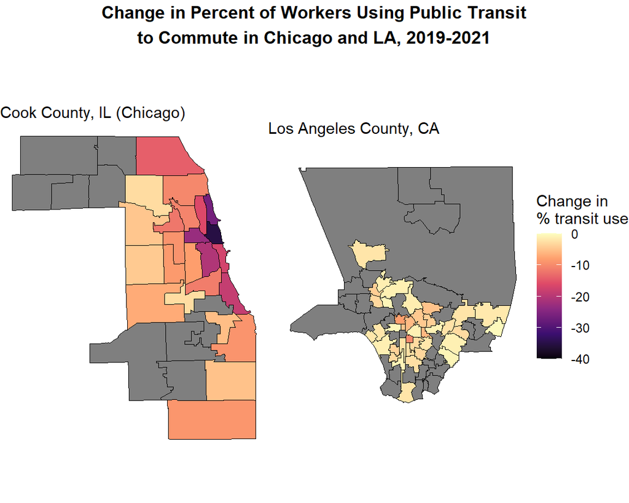